# IODS course project

Kristiina Suominen

# Introduction to Open Data Science - Course Project

# About the project

I have learned about the course Introduction to Open Data Science through my PhD studies. I’m exited to start the course but also a bit worried about the workload. The course Moodle page seems to contain **a lot** of information, so probably will take a while to get a handle on things.

I have previously used R and Rstudio on some courses, but I’m no expert. I think that exercise 1 was too long, and all in all there was too much stuff to be learned about R in the first week. To me, this one really long exercise feels exhausting. It is nice that there are the R codes already embedded, but I feel smaller chunks would be better. If I hadn’t done R before, I would be terrified right now.

[Link to my GitHub repository](https://github.com/ksuominen/IODS-project)

# Regression and model validation

```r
date()
```

```
## [1] "Mon Nov 21 17:34:36 2022"
```

```r
library(tidyverse)
students2014 <- read_csv("./data/learning2014.csv")
dim(students2014)
```

```
## [1] 166   7
```

```r
str(students2014)
```

```
## spec_tbl_df [166 x 7] (S3: spec_tbl_df/tbl_df/tbl/data.frame)
##  $ gender  : chr [1:166] "F" "M" "F" "M" ...
##  $ age     : num [1:166] 53 55 49 53 49 38 50 37 37 42 ...
##  $ attitude: num [1:166] 3.7 3.1 2.5 3.5 3.7 3.8 3.5 2.9 3.8 2.1 ...
##  $ deep    : num [1:166] 3.58 2.92 3.5 3.5 3.67 ...
##  $ stra    : num [1:166] 3.38 2.75 3.62 3.12 3.62 ...
##  $ surf    : num [1:166] 2.58 3.17 2.25 2.25 2.83 ...
##  $ points  : num [1:166] 25 12 24 10 22 21 21 31 24 26 ...
##  - attr(*, "spec")=
##   .. cols(
##   ..   gender = col_character(),
##   ..   age = col_double(),
##   ..   attitude = col_double(),
##   ..   deep = col_double(),
##   ..   stra = col_double(),
##   ..   surf = col_double(),
##   ..   points = col_double()
##   .. )
```

## Basic information about dataset

Dataset is created from data: https://www.mv.helsinki.fi/home/kvehkala/JYTmooc/JYTOPKYS3-meta.txt  
Data is collected from students in course ‘Johdatus yhteiskuntatilastotieteeseen’ in fall 2014.

Dataset students2014 contains 7 variables with 166 observations: gender, age, attitude, deep, stra, surf, and points.

All variables in the original data related to strategic, deep, and surface learning have been combined into three variables (stra, deep, and surf, respectively), and scaled to original scales by taking the mean.

Attitude tells about student’s global attitude towards statistics. Variable has been scaled back to the original scale of the questions, by dividing it with the number of questions.

Points tells the course exam points. Observations with points equaling 0 have been excluded, since those students didn’t attend the course exam.

```r
library(GGally)
```

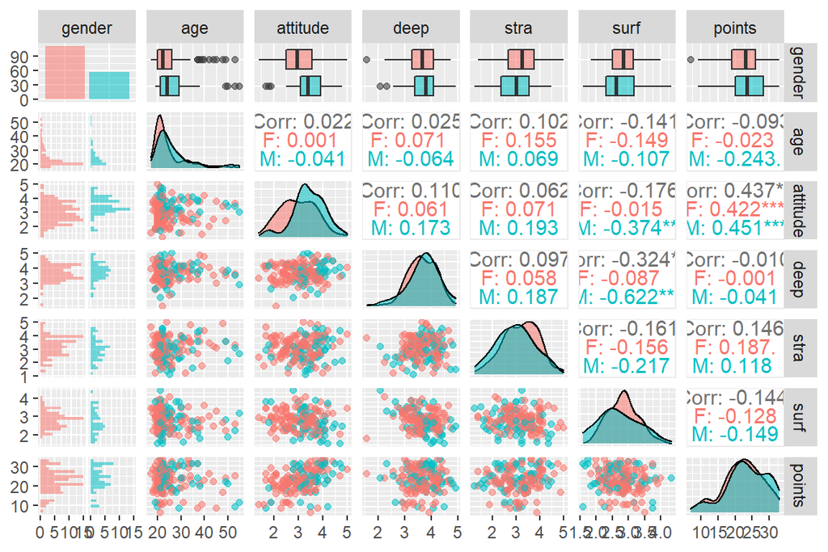

```r
library(ggplot2)

# create a plot matrix with ggpairs()
p <- ggpairs(students2014, mapping = aes(col=gender, alpha=0.3), lower = list(combo = wrap("facethist", bins = 20)))
p
```

```r
summary(factor(students2014$gender))
```

```
##   F   M
## 110  56
```

```r
summary(students2014$age)
```

```
##    Min. 1st Qu.  Median    Mean 3rd Qu.    Max.
##   17.00   21.00   22.00   25.51   27.00   55.00
```

```r
summary(students2014$attitude)
```

```
##    Min. 1st Qu.  Median    Mean 3rd Qu.    Max.
##   1.400   2.600   3.200   3.143   3.700   5.000
```

```r
summary(students2014$deep)
```

```
##    Min. 1st Qu.  Median    Mean 3rd Qu.    Max.
##   1.583   3.333   3.667   3.680   4.083   4.917
```

```r
summary(students2014$stra)
```

```
##    Min. 1st Qu.  Median    Mean 3rd Qu.    Max.
##   1.250   2.625   3.188   3.121   3.625   5.000
```

```r
summary(students2014$surf)
```

```
##    Min. 1st Qu.  Median    Mean 3rd Qu.    Max.
##   1.583   2.417   2.833   2.787   3.167   4.333
```

```r
summary(students2014$points)
```

```
##    Min. 1st Qu.  Median    Mean 3rd Qu.    Max.
##    7.00   19.00   23.00   22.72   27.75   33.00
```

## Describing the data

There are 66% (110/166) women in respondents. The median age is 22 years (range 17-55), the median age of women seems to be a bit lower than that of men.

The median attitude is 3.2 (range 1.4-5). The median attitude of men seems higher than that of women.

The median for deep learning is 3.7 (range 1.6-4.9). The median for strategic learning is 3.1 (range 1.3-5). The median for surface learning is 2.8 (range 1.6-4.3). For women, the median for strategic and surface learning seems a bit higher than for men.

The median for exam points is 23 (range 7-33). The median is about the same in men and women.

Attitude correlates with exam points, so that with “better” attitude towards statistics one usually gets higher exam points.

Surface learning correlates negatively with deep and strategic learning as well as attitude. So with better attitude one less often utilizes surface learning. If one utilizes surface learning, one less often utilizes deep or strategic learning.

```r
#fit a linear regression model using points as the outcome and attitude, strategig and surface learning as explanatory variables
my_model <- lm(points ~ attitude + stra + surf, data = students2014)
summary(my_model)
```

```
##
## Call:
## lm(formula = points ~ attitude + stra + surf, data = students2014)
##
## Residuals:
##      Min       1Q   Median       3Q      Max
## -17.1550  -3.4346   0.5156   3.6401  10.8952
##
## Coefficients:
##             Estimate Std. Error t value Pr(>|t|)
## (Intercept)  11.0171     3.6837   2.991  0.00322 **
## attitude      3.3952     0.5741   5.913 1.93e-08 ***
## stra          0.8531     0.5416   1.575  0.11716
## surf         -0.5861     0.8014  -0.731  0.46563
## ---
## Signif. codes:  0 '***' 0.001 '**' 0.01 '*' 0.05 '.' 0.1 ' ' 1
##
## Residual standard error: 5.296 on 162 degrees of freedom
## Multiple R-squared:  0.2074, Adjusted R-squared:  0.1927
## F-statistic: 14.13 on 3 and 162 DF,  p-value: 3.156e-08
```

```r
#remove surface learning from the model, since it's so far from significant
my_model2 <- lm(points ~ attitude + stra, data = students2014)
summary(my_model2)
```

```
##
## Call:
## lm(formula = points ~ attitude + stra, data = students2014)
##
## Residuals:
##      Min       1Q   Median       3Q      Max
## -17.6436  -3.3113   0.5575   3.7928  10.9295
##
## Coefficients:
##             Estimate Std. Error t value Pr(>|t|)
## (Intercept)   8.9729     2.3959   3.745  0.00025 ***
## attitude      3.4658     0.5652   6.132 6.31e-09 ***
## stra          0.9137     0.5345   1.709  0.08927 .
## ---
## Signif. codes:  0 '***' 0.001 '**' 0.01 '*' 0.05 '.' 0.1 ' ' 1
##
## Residual standard error: 5.289 on 163 degrees of freedom
## Multiple R-squared:  0.2048, Adjusted R-squared:  0.1951
## F-statistic: 20.99 on 2 and 163 DF,  p-value: 7.734e-09
```

```r
#error rate
sigma(my_model2)*100/mean(students2014$points)
```

```
## [1] 23.28148
```

## Interpreting the fitted regression model

First we choose three variables that correlate the most with points in above visualization (namely attitude, strategic and surface learning). However, after fitting the model, we see that for surface learning there is a really high p-value (0.466), so we remove that and fit the model again with just attitude and strategic learning.

In the new model, p-value of the F-statistic is 7.734e-09. So at least one of the explanatory variables is significantly associated with exam points.

For attitude, p-value is <0.001, so it is significantly associated with exam points. According to this model, if attitude increases by 1, exam points increase by approximately 3.5.

For strategic learning, p-value is 0.089. It isn’t <0.05 that’s usually deemed significant, however, it is quite close. So we probably don’t want to state that strategic learning has no effect on exam points. On the other hand, the estimated intercept for strategic learning is 0.9, so a change in attitude makes a much bigger difference than a change in strategic learning.

The adjusted R-squared is 0.1951, which means that attitude (and strategic learning) only explain around 20% of the variance in exam points.

The residual standard error is 5.289 which corresponds to 23% prediction error rate.

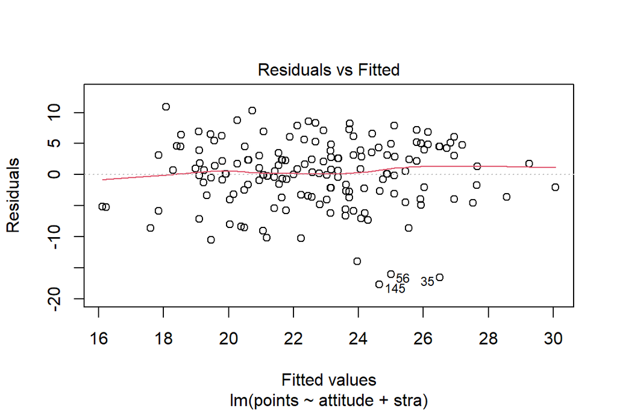

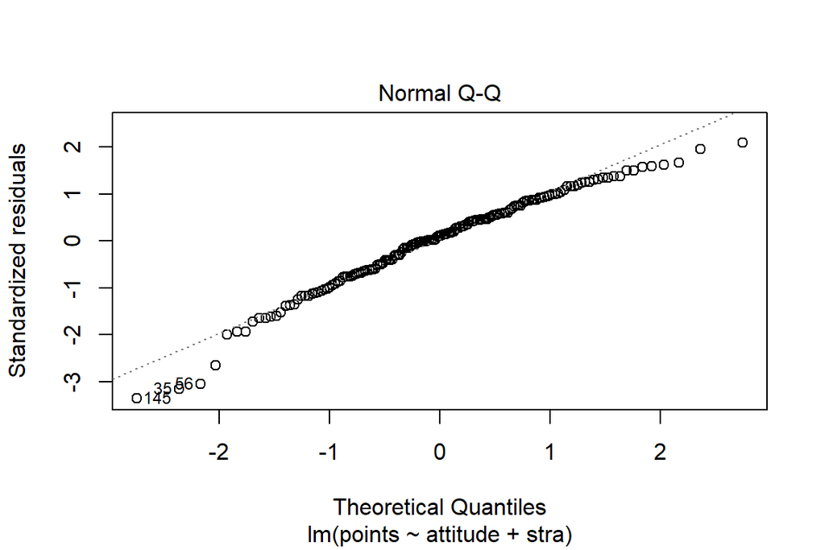

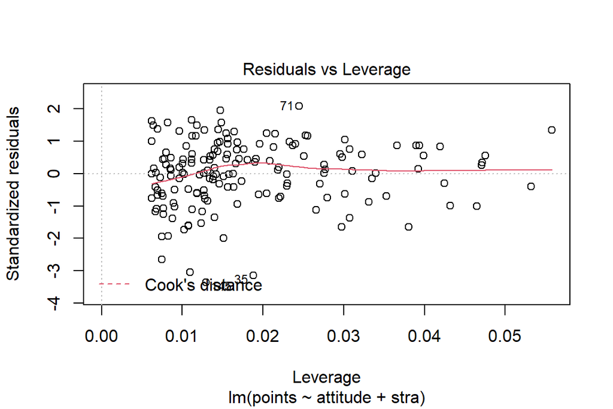

```r
plot(my_model2, which=c(1,2,5))
```

## Assumptions of the model

Linear regression assumes a linear relationship between predictors and outcome, that residual errors are normally distributed, that residuals have a constant variance, and independence of residual error terms.

With **Residuals vs. Fitted** plot we can check the linearity of data. Here, the red line seems to be horizontal at approximately zero, where it should be. So we can assume a linear relationship.

With plot **Normal Q-Q** we can check if residual errors are normally distributed. The plot of residuals should more or less follow the dashed line. Here they mostly do so, with some exceptions at the upper and lower ends. However, we may assume normality.

The **Residuals vs. Leverage** plot marks three most extreme points (35, 71, 145). Two of them exceed 3 standard deviations, so they are possible outliers.

# Logistic regression

```r
date()
```

```
## [1] "Mon Nov 21 17:34:47 2022"
```

```r
library(tidyverse)
alc <- read_csv("./data/alc.csv")
dim(alc)
```

```
## [1] 370  35
```

```r
colnames(alc)
```

```
##  [1] "school"     "sex"        "age"        "address"    "famsize"
##  [6] "Pstatus"    "Medu"       "Fedu"       "Mjob"       "Fjob"
## [11] "reason"     "guardian"   "traveltime" "studytime"  "schoolsup"
## [16] "famsup"     "activities" "nursery"    "higher"     "internet"
## [21] "romantic"   "famrel"     "freetime"   "goout"      "Dalc"
## [26] "Walc"       "health"     "failures"   "paid"       "absences"
## [31] "G1"         "G2"         "G3"         "alc_use"    "high_use"
```

## Short description of dataset

Dataset is created from data: https://archive.ics.uci.edu/ml/datasets/Student+Performance  
The data approaches student achievement in secondary education of two Portuguese schools, and the dataset joins two student alcohol consumption datasets. The variables not used for joining the two data have been combined by averaging (including the grade variables). ‘alc_use’ is the average of ‘Dalc’ and ‘Walc’. ‘high_use’ is TRUE if ‘alc_use’ is higher than 2 and FALSE otherwise.

Dataset alc contains 35 variables with 370 observations.

## My personal hypothesis about relationships of with alcohol consumption

I think interesting variables in relation to alcohol consumption are sex, number of past class failures, final grade (G3) and number of school absences.  
My hypothesis for these variables are:  
1. Men’s alcohol consumption is higher than women’s.  
2. Those who consume more alcohol have more past class failures compared to those who consume less alcohol.  
3. Those who consume more alcohol have lower final grades compared to those who consume less alcohol.  
4. Those who consume more alcohol have more school absences compared to those who consume less alcohol.

```r
library(dplyr); library(ggplot2); library(GGally); library(finalfit)


dependent <- "high_use"
explanatory <- c("sex", "failures", "G3", "absences")
alc %>%
  summary_factorlist(dependent, explanatory, p = TRUE,
                     add_dependent_label = TRUE)
```

```
##  Dependent: high_use                FALSE       TRUE      p
##                  sex         F 154 (59.5)  41 (36.9) <0.001
##                              M 105 (40.5)  70 (63.1)
##             failures         0 238 (91.9)  87 (78.4)  0.003
##                              1   12 (4.6)  12 (10.8)
##                              2    8 (3.1)    9 (8.1)
##                              3    1 (0.4)    3 (2.7)
##                   G3 Mean (SD) 11.8 (3.4) 10.9 (3.0)  0.011
##             absences Mean (SD)  3.7 (4.5)  6.4 (7.1) <0.001
```

```r
#median and quartiles of the numeric variables
summary(alc$failures)
```

```
##    Min. 1st Qu.  Median    Mean 3rd Qu.    Max.
##  0.0000  0.0000  0.0000  0.1892  0.0000  3.0000
```

```r
summary(alc$G3)
```

```
##    Min. 1st Qu.  Median    Mean 3rd Qu.    Max.
##    0.00   10.00   12.00   11.52   14.00   18.00
```

```r
summary(alc$absences)
```

```
##    Min. 1st Qu.  Median    Mean 3rd Qu.    Max.
##   0.000   1.000   3.000   4.511   6.000  45.000
```

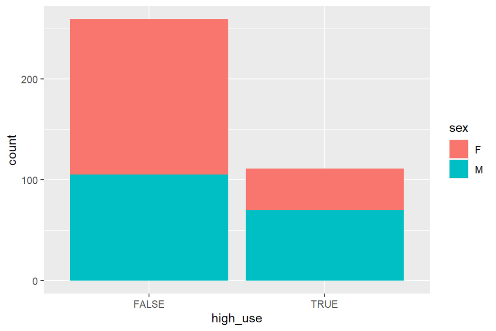

```r
#draw a barplot of alcohol consumption by sex
ggplot(data = alc, aes(x = high_use, fill=sex)) + geom_bar()
```

```r
#produce summary statistics of final grade by alcohol consumption and sex
alc %>% group_by(sex, high_use) %>% summarise(mean_grade=mean(G3),count = n())
```

```
## # A tibble: 4 x 4
## # Groups:   sex [2]
##   sex   high_use mean_grade count
##   <chr> <lgl>         <dbl> <int>
## 1 F     FALSE          11.4   154
## 2 F     TRUE           11.8    41
## 3 M     FALSE          12.3   105
## 4 M     TRUE           10.3    70
```

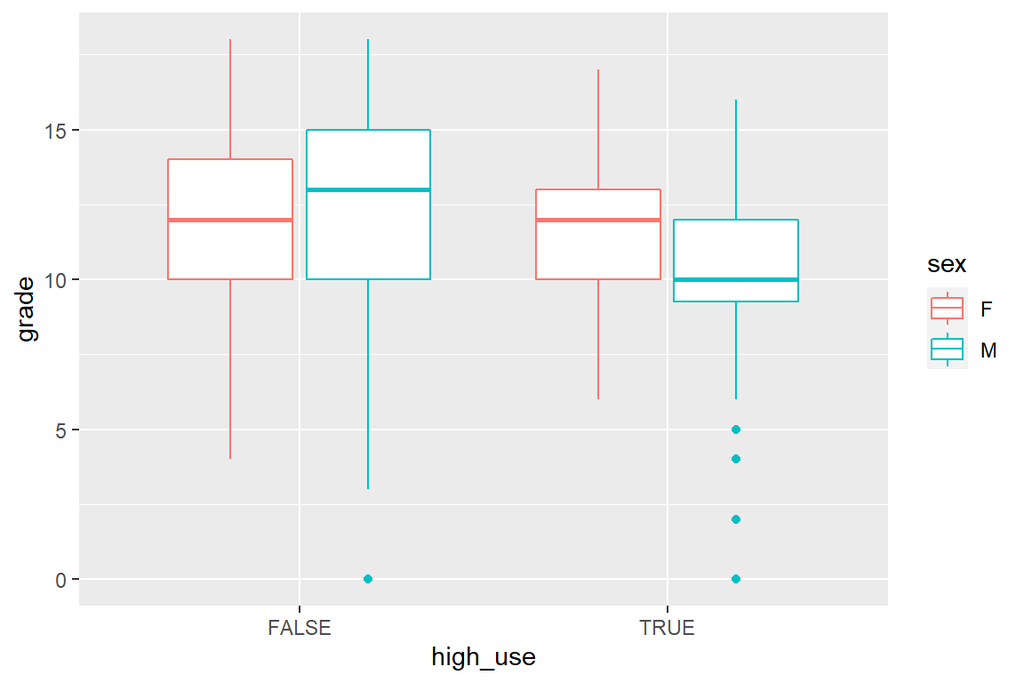

```r
#draw a boxplot of final grade by alcohol consumption and sex
ggplot(alc, aes(x = high_use, y = G3, col=sex)) + geom_boxplot() + ylab("grade")
```

```r
#produce summary statistics of school abscences by alcohol consumption and sex
alc %>% group_by(sex, high_use) %>% summarise(mean_absences=mean(absences),count = n())
```

```
## # A tibble: 4 x 4
## # Groups:   sex [2]
##   sex   high_use mean_absences count
##   <chr> <lgl>            <dbl> <int>
## 1 F     FALSE             4.25   154
## 2 F     TRUE              6.85    41
## 3 M     FALSE             2.91   105
## 4 M     TRUE              6.1     70
```

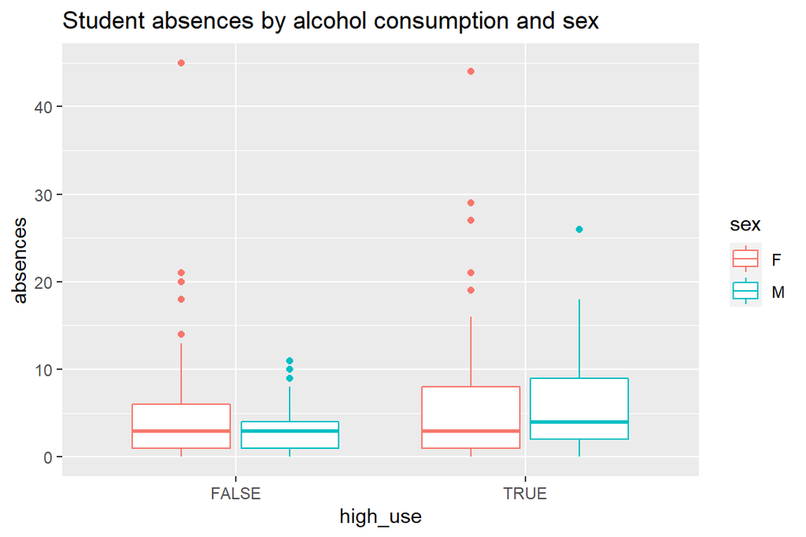

```r
#draw a boxplot of school absences by alcohol consumption and sex
ggplot(alc, aes(x = high_use, y = absences, col=sex)) + geom_boxplot() + ylab("absences") + ggtitle("Student absences by alcohol consumption and sex")
```

## Description of chosen variables and their relationships with alcohol consumption

There are 195 women and 175 men. Of those, 21% (41/195) and 40% (70/175) have high alcohol consumption, respectively. This supports my hypothesis of men consuming more alcohol than women.

The mean of past class failures is 0.2 (range 0-3). Of high users, 3% (3/111) have 3 failures, 8% (9/111) have 2 failures, and 11% have 1 failure. Of others, 0.4% (1/259) have 3 failures, 3% (8/259) have 2 failures, and 5% have 1 failure. Thus it would seem that students with high alcohol consumption have failed class more often than those with low alcohol consumption.

The mean final grade is 11.5 (range 0-18). Men with high alcohol consumption seem to have lower final grades than people with low alcohol consumption. Interestingly, women with high alcohol consumption seem to have around the same final grades than people with low alcohol consumption. So my hypothesis is supported only by observations of men.

The mean number of absences is 4.5 (range 0-45, median 3). The median of school absences is higher for men with high alcohol consumption than other groups. However, if we look at the mean, women with high alcohol consumption have the highest mean of absences, and both men and women with high alcohol consumption have higher mean than those with low alcohol consumption. This is somewhat in line with my hypothesis.

```r
# fit a logistic regression model
my_model <- glm(high_use ~ sex + failures + absences + G3, data = alc, family = "binomial")

# print out a summary of the model
summary(my_model)
```

```
##
## Call:
## glm(formula = high_use ~ sex + failures + absences + G3, family = "binomial",
##     data = alc)
##
## Deviance Residuals:
##     Min       1Q   Median       3Q      Max
## -2.1561  -0.8429  -0.5872   1.0033   2.1393
##
## Coefficients:
##             Estimate Std. Error z value Pr(>|z|)
## (Intercept) -1.38733    0.51617  -2.688  0.00719 **
## sexM         1.00870    0.24798   4.068 4.75e-05 ***
## failures     0.50382    0.22018   2.288  0.02213 *
## absences     0.09058    0.02322   3.901 9.56e-05 ***
## G3          -0.04671    0.03948  -1.183  0.23671
## ---
## Signif. codes:  0 '***' 0.001 '**' 0.01 '*' 0.05 '.' 0.1 ' ' 1
##
## (Dispersion parameter for binomial family taken to be 1)
##
##     Null deviance: 452.04  on 369  degrees of freedom
## Residual deviance: 405.59  on 365  degrees of freedom
## AIC: 415.59
##
## Number of Fisher Scoring iterations: 4
```

```r
# fit a new model without G3 model
my_model2 <- glm(high_use ~ sex + failures + absences, data = alc, family = "binomial")

# print out a summary of the model
summary(my_model2)
```

```
##
## Call:
## glm(formula = high_use ~ sex + failures + absences, family = "binomial",
##     data = alc)
##
## Deviance Residuals:
##     Min       1Q   Median       3Q      Max
## -2.1550  -0.8430  -0.5889   1.0328   2.0374
##
## Coefficients:
##             Estimate Std. Error z value Pr(>|z|)
## (Intercept) -1.94150    0.23129  -8.394  < 2e-16 ***
## sexM         0.99731    0.24725   4.034 5.49e-05 ***
## failures     0.59759    0.20698   2.887  0.00389 **
## absences     0.09245    0.02323   3.979 6.91e-05 ***
## ---
## Signif. codes:  0 '***' 0.001 '**' 0.01 '*' 0.05 '.' 0.1 ' ' 1
##
## (Dispersion parameter for binomial family taken to be 1)
##
##     Null deviance: 452.04  on 369  degrees of freedom
## Residual deviance: 406.99  on 366  degrees of freedom
## AIC: 414.99
##
## Number of Fisher Scoring iterations: 4
```

```r
# compute odds ratios (OR)
OR <- coef(my_model2) %>% exp

# compute confidence intervals (CI)
CI <- confint(my_model2) %>% exp
# print out the odds ratios with their confidence intervals
cbind(OR, CI)
```

```
##                    OR      2.5 %    97.5 %
## (Intercept) 0.1434892 0.08940913 0.2219242
## sexM        2.7109881 1.67967829 4.4367282
## failures    1.8177381 1.21997630 2.7642305
## absences    1.0968598 1.05041937 1.1508026
```

## Logistic regression

In the first model, final grade has a p-value 0.2, and thus isn’t associated with high alcohol consumption. Let’s fit the model again without it. In the second model, all variables are associated with the outcome, and also the AIC drops from 415.59 to 414.99, which indicates that G3 can be dropped from the model.

According to this model, high alcohol consumption is associated with being male (OR 2.7, 95% CI 1.7-4.4, p-value <0.001), having failed class (OR 1.8, 95% CI 1.2-2.8, p-value 0.004), and school absences (OR 1.1, 95% CI 1.1-1.2, p-value <0.001).  
My primary hypothesis were correct regarding being male and having failed classes. However, there is only slight association with school absence (OR 1.1), and the final grade doesn’t seem to be associated with high alcohol consumption.

```r
# predict() the probability of high_use
probabilities <- predict(my_model2, type = "response")

library(dplyr)
# add the predicted probabilities to 'alc'
alc <- mutate(alc, probability = probabilities)

# use the probabilities to make a prediction of high_use
alc <- mutate(alc, prediction = probability>0.5)

# tabulate the target variable versus the predictions
table(high_use = alc$high_use, prediction = alc$prediction)
```

```
##         prediction
## high_use FALSE TRUE
##    FALSE   252    7
##    TRUE     78   33
```

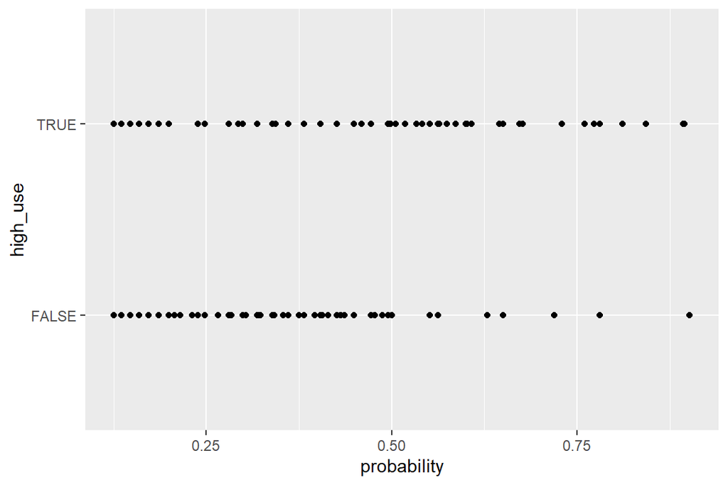

```r
# draw a plot of 'high_use' versus 'probability' in 'alc'
ggplot(alc, aes(x = probability, y = high_use)) + geom_point()
```

```r
# define a loss function (mean prediction error)
loss_func <- function(class, prob) {
  n_wrong <- abs(class - prob) > 0.5
  mean(n_wrong)
}

# call loss_func to compute the average number of wrong predictions in the (training) data
loss_func(class = alc$high_use, prob = alc$probability)
```

```
## [1] 0.2297297
```

## Predictive power of the model

In the 2x2 table we can see that 252 low and 33 high alcohol consumers are predicted correctly. In the predictions, however, there are 78 false negatives and 7 false positives. According to the training error, 23% of the individuals are classified inaccurately. This is better than tossing a coin (where the chances would be 50/50), but I guess with some background information one could get quite close with educated guesses.

```r
# 10-fold cross-validation
library(boot)
cv <- cv.glm(data = alc, cost = loss_func, glmfit = my_model2, K = 10)

# average number of wrong predictions in the cross validation
cv$delta[1]
```

```
## [1] 0.2351351
```

```r
#Let's try the same with another model.
my_model3 <- glm(high_use ~ traveltime + sex + absences +studytime + goout, data = alc, family = "binomial")
summary(my_model3)
```

```
##
## Call:
## glm(formula = high_use ~ traveltime + sex + absences + studytime +
##     goout, family = "binomial", data = alc)
##
## Deviance Residuals:
##     Min       1Q   Median       3Q      Max
## -1.8435  -0.7908  -0.4914   0.6936   2.5211
##
## Coefficients:
##             Estimate Std. Error z value Pr(>|z|)
## (Intercept) -3.72342    0.67103  -5.549 2.88e-08 ***
## traveltime   0.35147    0.18157   1.936 0.052908 .
## sexM         0.81643    0.27225   2.999 0.002710 **
## absences     0.07919    0.02293   3.454 0.000552 ***
## studytime   -0.40974    0.17327  -2.365 0.018041 *
## goout        0.71830    0.12152   5.911 3.40e-09 ***
## ---
## Signif. codes:  0 '***' 0.001 '**' 0.01 '*' 0.05 '.' 0.1 ' ' 1
##
## (Dispersion parameter for binomial family taken to be 1)
##
##     Null deviance: 452.04  on 369  degrees of freedom
## Residual deviance: 363.51  on 364  degrees of freedom
## AIC: 375.51
##
## Number of Fisher Scoring iterations: 4
```

```r
prob2 <- predict(my_model3, type = "response")
loss_func(class = alc$high_use, prob = prob2)
```

```
## [1] 0.2027027
```

```r
cv2 <- cv.glm(data = alc, cost = loss_func, glmfit = my_model3, K = 10)
cv2$delta[1]
```

```
## [1] 0.227027
```

## 10-fold cross-validation of the model

The prediction error of the model when using 10-fold cross-validation is around 0.24, which is slightly less than in the exercise set.  
With the other tested model (explanatory variables being sex, home to school travel time, number of school absences, weekly study time, and going out with friends), the prediction error with 10-fold cross-validation is around 0.22, which is still lower.

(more chapters to be added similarly as we proceed with the course!)